# Friends TV show analysis

EDAV Final Project

Alberto Munguia, Ivan Ugalde & Bernardo Lopez

## Data sources

We used two different data sets:

- Chapter ratings from IMBD website https://www.imdb.com/interfaces/.
- Dialogues from https://fangj.github.io/friends/,

To get Dialogues data we will use **rvest** package for web scraping.

First we check if we are allowed to extract data from that website.

```r
url <- "https://fangj.github.io/friends/"
paths_allowed(url)
```

```
## [1] TRUE
```

```
## # A tibble: 6 x 5
##   episode_id line_num scene character line
##   <chr>         <dbl> <dbl> <chr>     <chr>
## 1 1 : 01            1     1 MONICA    There's nothing to tell! He's just s…
## 2 1 : 01            2     1 JOEY      C'mon, you're going out with the guy…
## 3 1 : 01            3     1 CHANDLER  All right Joey, be nice. So does he …
## 4 1 : 01            4     1 PHOEBE    Wait, does he eat chalk?
## 5 1 : 01            5     1 PHOEBE    Just, 'cause, I don't want her to go…
## 6 1 : 01            6     1 MONICA    Okay, everybody relax. This is not e…
```

## Data transformation

Add word count to dialogues.

```
## # A tibble: 6 x 2
##   line                                                                words
##   <chr>                                                               <int>
## 1 There's nothing to tell! He's just some guy I work with!               11
## 2 C'mon, you're going out with the guy! There's gotta be something w…    14
## 3 All right Joey, be nice. So does he have a hump? A hump and a hair…    16
## 4 Wait, does he eat chalk?                                                5
## 5 Just, 'cause, I don't want her to go through what I went through w…    16
## 6 Okay, everybody relax. This is not even a date. It's just two peop…    21
```

We can see that some episodes where put together in the same file:

```
## [1] "2 : 12-13"  "6 : 15-16"  "9 : 23-24"  "10 : 17-18"
```

Now we split those episodes into two different ones:

For more clarity, we will add season and episode columns.

Now we have to correct some character names that had typos.

```
## # A tibble: 6 x 8
##   episode_id line_num scene character line             words season episode
##   <chr>         <dbl> <dbl> <chr>     <chr>            <int>  <int>   <int>
## 1 1 : 01            1     1 MONICA    There's nothing…    11      1       1
## 2 1 : 01            2     1 JOEY      C'mon, you're g…    14      1       1
## 3 1 : 01            3     1 CHANDLER  All right Joey,…    16      1       1
## 4 1 : 01            4     1 PHOEBE    Wait, does he e…     5      1       1
## 5 1 : 01            5     1 PHOEBE    Just, 'cause, I…    16      1       1
## 6 1 : 01            6     1 MONICA    Okay, everybody…    21      1       1
```

More data transformation will be used and explained in each of the Results subsections.

## Missing values

To search for missing values we look at the number of missing values per columns in **dialouges**.

```
## episode_id   line_num      scene  character       line      words
##          0          0          0          0         62          0
##     season    episode
##          0          0
```

There appear to be some missing values for line column. We will use **visna** from **extracats** library to see the pattern of missing values.

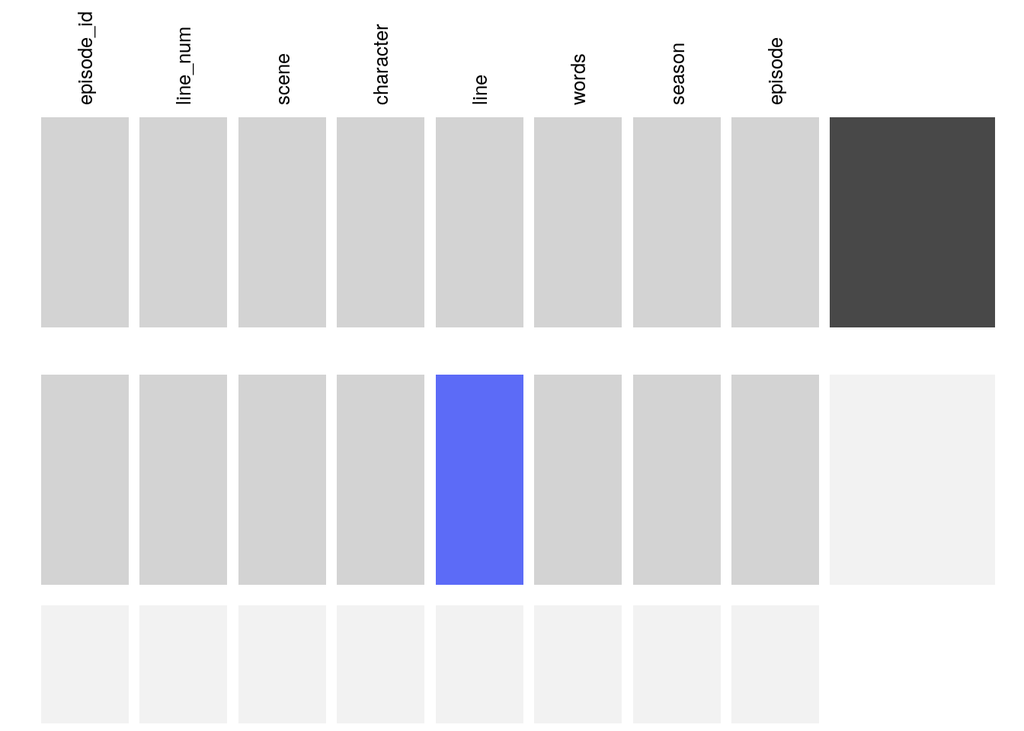

This missing values are due to a different formats in the Git Hub page used for web scraping. For example, lines like “Paolo: (something in Italian)” render a NA line because the scraping code removes everything between parenthesis.

We decided to fill those missing values with “-”. By doing so we will keep the register for those characters dialogue.

This is not a problem because there are only 62 lines with this issue. This is a really small number compared with the total number of lines (more than 61 thousand).

We see that we do not have NA’s in the data after scraping and data transformation process.

## Results

### Main characters

Friends is a TV show that tells the story of a group of six friends: **Monica**, **Rachel**, **Phoebe**, **Chandler**, **Ross** and **Joey**. Is one of these characters more important than others? We try to answer this question by looking at the number of lines for each of these main characters.

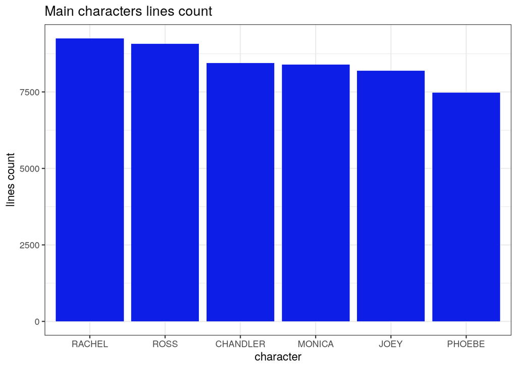

We can see that Rachel is the character with more lines and Phoebe is the character with less lines. Now we focus in the number of words instead of the number of lines.

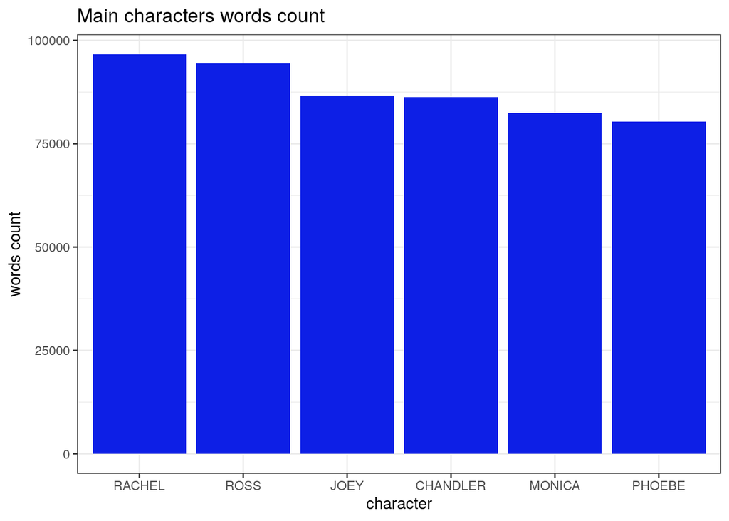

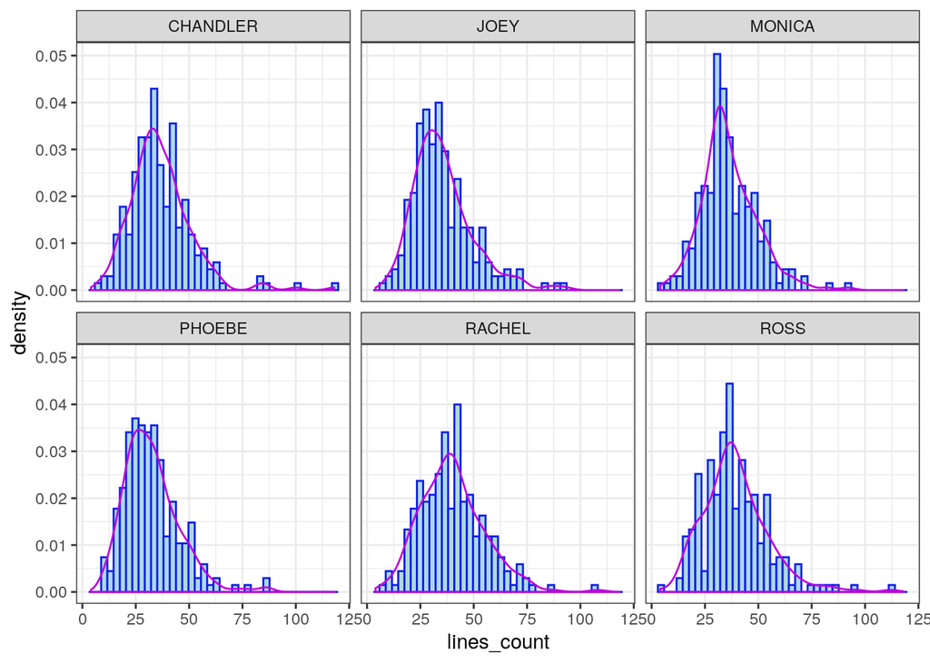

By looking into lines per episode distribution we find the following: * Monica’s distribution looks more narrow that the others. This indicates that there are few episodes in which Monica speaks a lot. * Chandler and Ross have large right tails, we infer that those characters have episodes in which they speak a lot. * Rachel and Ross have wider distributions.

### LDA Topic modelling

For topic modelling we will use the package **textmineR**. We will try to find the topic for each episode. To do so we will create a document for each episode, so we have to group lines by episode_id.

```
## # A tibble: 6 x 2
##   episode_id lines
##   <chr>      <chr>
## 1 1 : 01     There's nothing to tell! He's just some guy I work with! C'mo…
## 2 1 : 02     What you guys don't understand is, for us, kissing is as impo…
## 3 1 : 03     Hi guys! Hey, Pheebs! Hi! Hey. Oh, oh, how'd it go? Um, not s…
## 4 1 : 04     "Alright. Phoebe? Okay, okay. If I were omnipotent for a day,…
## 5 1 : 05     "Would you let it go? It's not that big a deal. Not that big …
## 6 1 : 06     Ooh! Look! Look! Look! Look, there's Joey's picture! This is …
```

Function CrateDtm creates a document term matrix. To do so we use a group of stopwords, words we don’t want to use because they are used frequently in English language and do not give insightful information.

We will use document term matrix to create a Term Document Frequency matrix that counts the number of times a term appears (term frequency) and the number of documents in which a term appears (document frequency).

These are the main terms ordered by term frequency:

```
##        term term_freq doc_freq
## 11662  good      1715      231
## 11661   god      1677      228
## 11660  guys      1468      225
## 11659 great      1342      225
## 11658  time      1216      229
## 11657  back      1128      223
```

Now we fit a Latent Dirichlet allocation model in which we will try to fit 15 topics into the collection of episodes. This will return to main matrices:

- **theta**: Matrix with the probability of topic per document -> P(topic | document).
- **phi**: Matrix with the probability of term per topic -> P(term | topic).

```
## [1] "Theta:"
```

```
##               t_1          t_2          t_3          t_4          t_5
## 1 : 01 0.02126022 0.0029822030 0.0000962001 0.0202982203 0.0010582011
## 1 : 02 0.07204696 0.0412325752 0.0001467351 0.2760088041 0.0001467351
## 1 : 03 0.10599222 0.0001556420 0.0032684825 0.0001556420 0.1106614786
## 1 : 04 0.05738452 0.0001301236 0.0014313598 0.0391672088 0.0547820429
## 1 : 05 0.01607531 0.0044895004 0.0001448226 0.0131788559 0.0001448226
## 1 : 06 0.03360000 0.0001454545 0.0059636364 0.0001454545 0.0001454545
```

```
## [1] "Phi:"
```

```
##          met_guy       gellar meeting_meeting cameras_smell    potpourri
## t_1 5.551793e-06 1.165876e-04    5.551793e-06  5.551793e-06 5.551793e-06
## t_2 1.013973e-05 1.013973e-05    1.013973e-05  1.013973e-05 1.013973e-05
## t_3 8.701554e-06 8.701554e-06    8.701554e-06  8.701554e-06 8.701554e-06
## t_4 8.072198e-06 8.072198e-06    8.072198e-06  8.072198e-06 8.072198e-06
## t_5 8.725851e-06 8.725851e-06    8.725851e-06  8.725851e-06 8.725851e-06
## t_6 6.826777e-06 6.826777e-06    6.826777e-06  6.826777e-06 1.433623e-04
```

Now the 15 topics have been created. To know about the topics quality we look into the **topic coherence**, this is a measure of how associated are words in a topic.

```
##      Min.   1st Qu.    Median      Mean   3rd Qu.      Max.
## 0.0002501 0.0159823 0.0427990 0.0509750 0.0746588 0.1676421
```

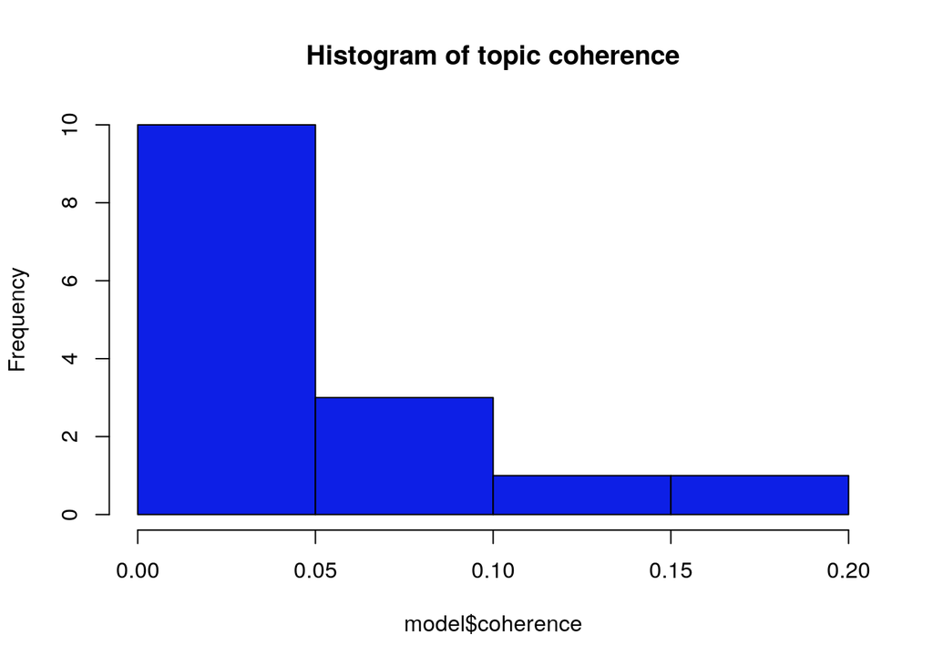

We will use phi to get the top 5 terms per topic.

```
##      [,1]           [,2]       [,3]       [,4]        [,5]
## t_1  "guys"         "married"  "night"    "moving"    "game"
## t_2  "thanksgiving" "cat"      "year"     "sister"    "happy"
## t_3  "joke"         "funny"    "car"      "show"      "story"
## t_4  "baby"         "babies"   "ben"      "carol"     "doctor"
## t_5  "party"        "birthday" "ben"      "christmas" "year"
## t_6  "date"         "guy"      "call"     "tonight"   "work"
## t_7  "good"         "god"      "time"     "great"     "guys"
## t_8  "god"          "naked"    "barry"    "blah"      "great"
## t_9  "emma"         "mike"     "alright"  "guys"      "charlie"
## t_10 "wedding"      "married"  "love"     "marry"     "ring"
## t_11 "alright"      "guys"     "tonight"  "fine"      "man"
## t_12 "play"         "janice"   "game"     "woman"     "kiss"
## t_13 "richard"      "dad"      "marcel"   "monkey"    "mom"
## t_14 "job"          "money"    "audition" "part"      "house"
## t_15 "emily"        "love"     "london"   "place"     "plane"
```

The next step is to compute the topic prevalence using theta. Topic prevalence indicate the most frequent topics in the TV show.

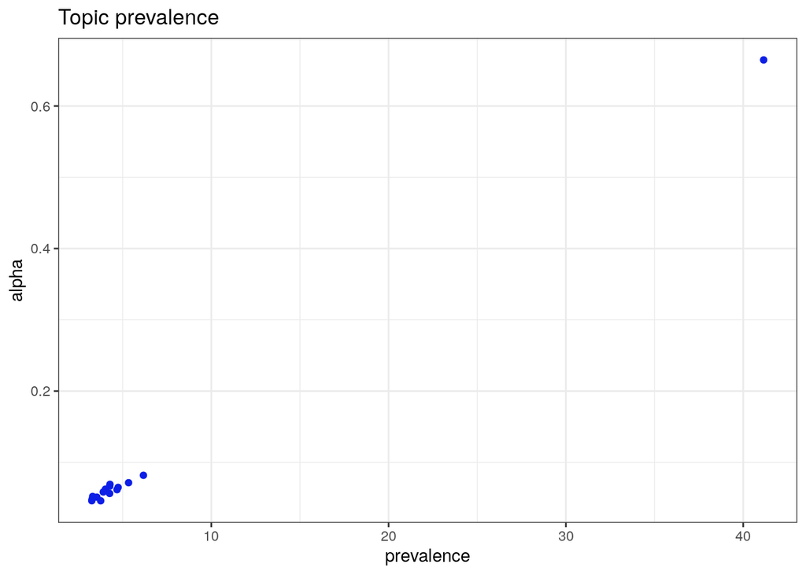

Finally, we get a summary for the complete LDA model.

```
##      topic coherence prevalence                              top_terms
## t_7    t_7     0.000     41.153           good, god, time, great, guys
## t_1    t_1     0.007      6.172     guys, married, night, moving, game
## t_6    t_6     0.018      5.334         date, guy, call, tonight, work
## t_14  t_14     0.049      4.745      job, money, audition, part, house
## t_11  t_11     0.010      4.683      alright, guys, tonight, fine, man
## t_10  t_10     0.099      4.285    wedding, married, love, marry, ring
## t_4    t_4     0.070      4.273       baby, babies, ben, carol, doctor
## t_12  t_12     0.044      4.267        play, janice, game, woman, kiss
## t_3    t_3     0.043      4.032          joke, funny, car, show, story
## t_5    t_5     0.019      3.908  party, birthday, ben, christmas, year
## t_8    t_8     0.014      3.761         god, naked, barry, blah, great
## t_2    t_2     0.043      3.546 thanksgiving, cat, year, sister, happy
## t_9    t_9     0.168      3.307     emma, mike, alright, guys, charlie
## t_13  t_13     0.079      3.273      richard, dad, marcel, monkey, mom
## t_15  t_15     0.103      3.260      emily, love, london, place, plane
```

We can see that the most prevalent (frequent) topic has words like “good”, “god”,“great”, “time”. This makes sense, this words are very frequent in the TV show and that is why they give very little information about the topic. That is why the coherence is 0.0.

The other topics in the model have less prevalence but they are more coherent. If you are a fan of the show and if you read the list of top terms, we are sure you can remember episodes in which those terms were important.

To find those important episodes we created a d3 tool. We wrote a csv file using theta in which, for each episode and topic we put the probability of that topic given the episode and the top terms of that topic.

```
##       id topic       value topic_num                          top_terms
## 1 1 : 01   t_1 0.021260221         1 guys, married, night, moving, game
## 2 1 : 01  t_14 0.004906205        14  job, money, audition, part, house
## 3 1 : 01   t_6 0.075132275         6     date, guy, call, tonight, work
## 4 1 : 01  t_15 0.001058201        15  emily, love, london, place, plane
## 5 1 : 01  t_13 0.096296296        13  richard, dad, marcel, monkey, mom
## 6 1 : 01   t_7 0.362770563         7       good, god, time, great, guys
##                     name
## 1 Monica Gets A Roommate
## 2 Monica Gets A Roommate
## 3 Monica Gets A Roommate
## 4 Monica Gets A Roommate
## 5 Monica Gets A Roommate
## 6 Monica Gets A Roommate
```

# Top episodes by topic